# Multi-scale Analysis of Forest Management Scenarios: Testing Indicators Forest Management Scenarios Overview

Clementine de Montgolfier

2025-09-23

# Abstract

This study is the beginning of a more comprehensive study on the effect of management strategies on forest multi-scale dynamics. It presents a multi-scale analysis of forest management scenarios using simulation outputs from the FORCEEPS model. Three silvicultural strategies—clear-cut management, continuous cover forestry, and natural evolution—were evaluated across multiple plots. Key indicators such as productivity, harvested volume, standing biomass, and diversity indices (Hill numbers) were calculated at both plot and landscape levels. The workflow includes scenario generation with repeated random plot assignments to assess variability, and comparative analysis of local versus global diversity to explore beta diversity. Results are visualized through temporal and relational plots, providing insights into the impacts of management strategies on forest structure and diversity.

# Initial Stand Conditions

| Surface (ha) | Stand Type | Silviculture Species | Dominant Species 1 | Dominant Species 2 | Structure & Soil Cover | Basal Area (m²/ha) | Mean DBH (cm) | Median Age (years) |
| --- | --- | --- | --- | --- | --- | --- | --- | --- |
| 2.50 | FHETE | HET | HET |  | F | 0.0 | 7.5 | 12.0 |
| 0.94 | FHET1 | HET | HET |  | F | 17.5 | 12.5 | 12.0 |
| 10.23 | FHETG | HET | HET | CHP | F | 21.0 | 57.5 | 144.5 |
| 4.59 | FHETG | HET | HET | CHS | F | 31.0 | 57.5 | 144.5 |
| 3.38 | FHETS | HET | HET | CHS | F | 0.0 | 3.5 | 12.0 |
| 1.73 | FCHPE | CHP | CHP |  | F | 0.0 | 7.5 | 12.0 |
| 3.10 | FCHSE | CHS | CHS |  | F | 0.0 | 7.5 | 12.0 |
| 1.28 | FDOUG- | DOU | DOU |  | F | 29.0 | 52.5 | 59.5 |
| 7.91 | FHETM | HET | HET | CHA | F | 31.0 | 37.5 | 114.5 |
| 2.23 | FCHPG+ | CHP | CHP | CHA | F | 17.5 | 62.5 | 125.0 |

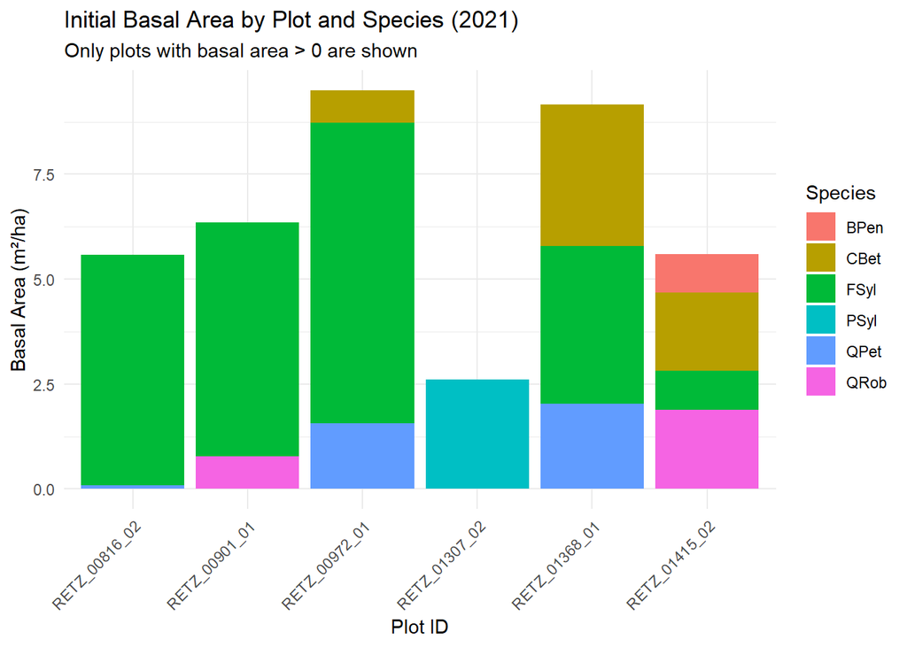

- Change `Generate.R` to include more diverse plot selection criteria.

Also in subsequent analyses I considered each plot as equal but for applicable results :

- Need to add a weight to account for plot size

# Itinerary exploration

The study evaluates three distinct silvicultural strategies:

- **Clear-cut management** *(simulation1)*
  - Management cutting every 10 years removing 30% of volume (cutting type 0.5)
  - While maintaining initial species composition
  - Final clear-cut at maturity age of the dominant species
- **Continuous cover forestry** *(simulation2)*
  - Partial cutting every 5 years removing 10% of volume (cutting type 0.5)
  - Targeting equal (25%) composition of the four (or less if not found) main species
  - **Note**: Harvesting only occurs when exploitability thresholds are met
- **Natural evolution** *(simulation3)*
  - No management intervention
  - Natural forest dynamics without human interference

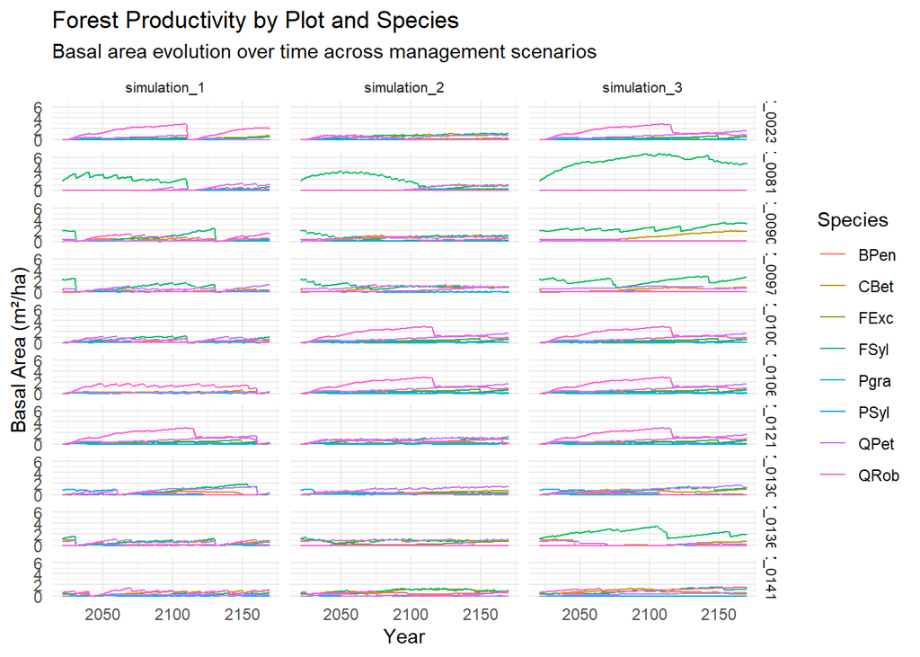

*Note: The decline in basal area observed in simulation 3 (natural evolution) likely results from natural mortality, as the management strategy is set to no intervention (150_3_0.5_0%_FSyl-80).*

# Plot-Level Indicators Calculation and Visualization

Over the 80-year simulation period, we calculate the following indicators:

- **Hill diversity indices** (richness, Shannon, Simpson, Hill 0, Hill 1, Hill 2)
- **Harvested volume** by scenario
- **Standing biomass** total and by species
- Work is needed to analyse structural diversity (either find a better forCEEPS output file or analyse the complete output file)

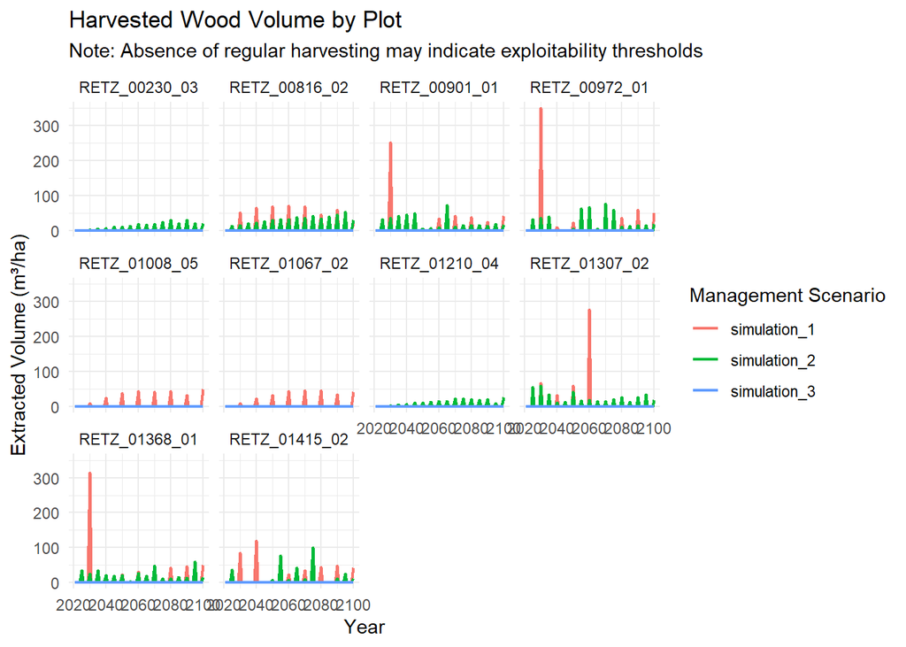

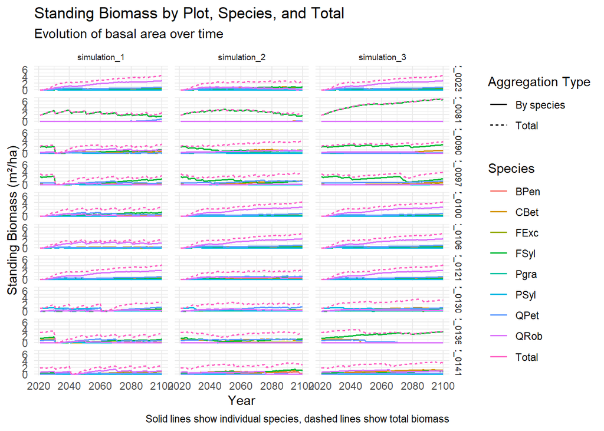

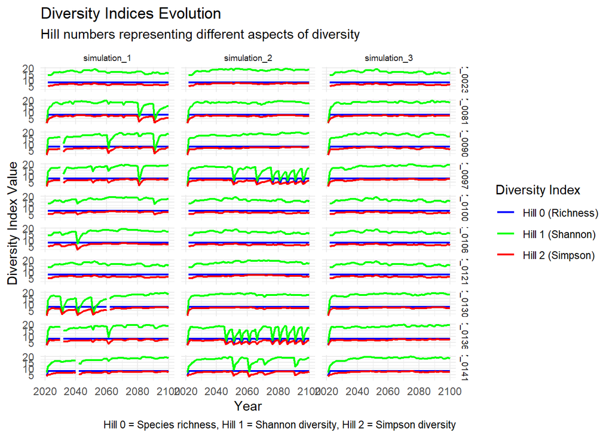

# Global Indicators

## Definition of Local vs Global Diversity

Before presenting the global indicators, it’s important to clarify the difference between local and global diversity measures:

- **Local diversity (Hill local)**: Average diversity calculated within each individual plot, then averaged across all plots in a scenario. This represents the typical diversity found in a single forest stand.
- **Global diversity (Hill global)**: Diversity calculated by pooling all species abundances across all plots in a scenario before computing the diversity index. This represents the overall landscape-level diversity.

The relationship between local and global diversity provides insights into beta diversity (turnover between plots). When global diversity is higher than local diversity, it indicates high species turnover between plots.

To create scenarios I combined different itineraries together.

To be able to conclude on different proportions effect and to take into account that the dynamic of one scenario can depend on which plot were chosen I repeated each scenarios 10 time. Example: for half clearcut, half no management, I randomly selected half of the plots for each itinerary and repeated this process 10 times to capture variability in the results.

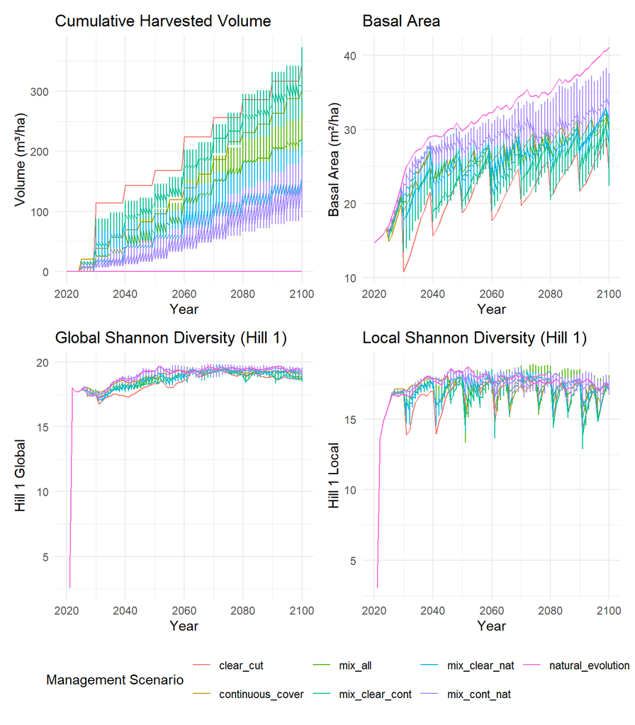

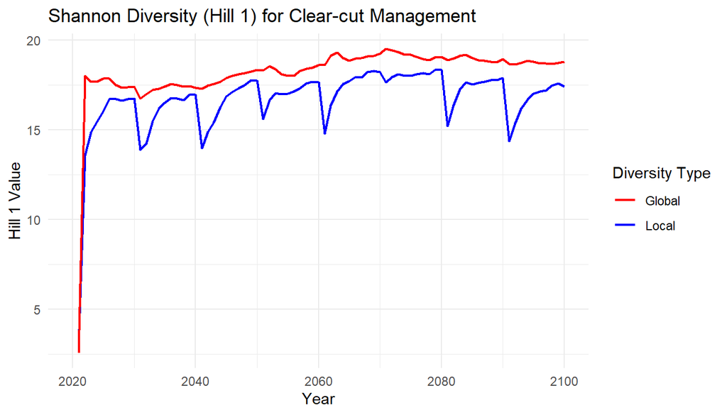

# Relationships Between Global Indicators

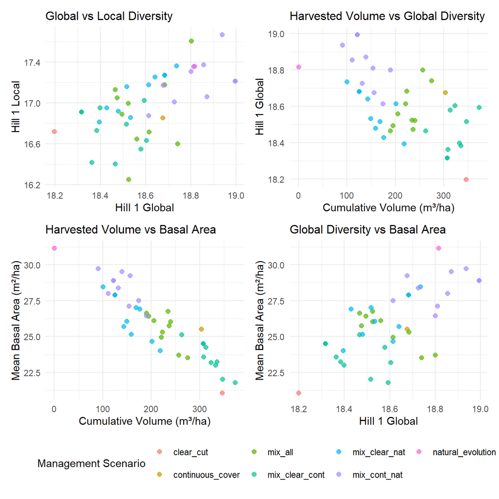

# Future Work

- **Select more diverse and representative plots** to better capture forest heterogeneity
- **Add additional indicators** (structure, canopy cover, recruitment, dead biomass)
- **Implement calculations with complete dataset** (code to be written and memory-optimized) as this may be necessary for structural diversity indices (needs consideration, but potentially no other output will contain the necessary data)
- **Integrate FORCEEPS replications** to calculate means and assess how this fits into the workflow

# Thoughts on future work, interest and limitations

From my point of view this is the most interesting part of the work we did together. I think this workflow is a good basis to start from and can be improved in many ways.

From here the questions that would motivate me is : **How can we caracterize our landscape ?** This is a complicated question in many ways. First because we want comprehensible indicators that can both describe **local and global characteristics** of the forest. Should we use proportion of stands (taking into account their size or not ?) ? Surface ? Or aggregated indicators (mean basal area, mean diversity …) ? Distributions ? Maps ? Secondly because those indicators needs not only to describe a fixed **forest state but also its dynamics**, we need to be able to see their evolution through time. Thirdly because some indicator are more difficult to access and proxies might be necessary.

Then the following question will easily be : **How these different indicators interact with each other ?**

Finally this will lead to : **How do different management strategies impact these characteristics ?** How can we manage our forest to maintain or improve these characteristics ? This questions raise one limitation that I met during this work : the difficulty to create archetypical (but interesting) scenarios. I think this is a very important point to work on in the future.